# Quarto Shiny Apps in R Packages

Modules, launching and deployment

Documentation

Shiny

Package Development

Author

Martin Frigaard

Published

February 6, 2025

This post was prompted by a new chapter I’ve been working on for Shiny App-Packages. I’ve recently been building a Shiny application in a Quarto document[^1], and noticed quite a few deviations from the standard app-package practices that deserve some attention.

I’ll cover various dashboard/html layout options, including modules in a Quarto document, and how to create a standalone function to launch your Quarto + Shiny app from an app-package.

## Set up

The Quarto document (`index.qmd`) is placed inside the `inst/` folder with a [`_quarto.yml` project file](https://quarto.org/docs/projects/quarto-projects.html#project-metadata):

```
└── inst
     └── quarto
          ├── _quarto.yml
          └── index.qmd
```

### `_quarto.yml`

`_quarto.yml` contains metadata on the format, style, and rendering options for the dashboard.

```yaml
title: "Quarto Movies App"

format:
  html:
    embed-resources: true
```

This file includes options for the entire Quarto project (i.e., all `.qmd` files in the folder). In our case it’s simply the dashboard file: `index.qmd`.

### `index.qmd`

The `index.qmd` file contains the `title` of our application and the `format` of the document in the YAML frontmatter.

```
---
title: "Movies App"
format: html
server: shiny
---
```

### `www/`

To include resources (like images or stylesheets), we’ll also add a `www/` folder:

```
└── inst
     └── quarto
          ├── _quarto.yml
          ├── index.qmd
          └── www/
              └── quarto.png
```

### `context: setup`

The first code chunk in `index.qmd` should include a `context: setup` option and load the necessary packages. If we want the dashboard to have access to the resources in `www/`, we need to include the [`addResourcePath()` function](https://shiny.posit.co/r/reference/shiny/0.12.0/addresourcepath.html) and pass the path with the installed version of our application.

````
```{r}
#| context: setup
# pkgs -------
library(sap)
library(thematic)
library(ragg)
# resources --------
addResourcePath(
    prefix = 'quarto',
    directoryPath = system.file('www', package = 'sap'))
```
````

## Dashboards

Dashboard layouts are covered extensively in the Quarto documentation[^2] and elsewhere[^3], and I’ve included example layouts in the [code repo](https://github.com/mjfrigaard/quarto-dash-r). Key things to remember about Quarto dashboard layouts:

### `format: dashboard`

1. Dashboard layouts are configured using a combination of YAML fields and markdown headings. By default, the `orientation` field is set to `rows`, but multiple code chunks will add new columns:

   ```yaml
   format:
     dashboard:
       orientation: columns
   ```

2. Level 1 headers create pages (with titles)

   ```markdown
   # Page 1
   ```

3. Level 2 and 3 headers create columns and rows (with height and width options)

   ```markdown
   ## Row {height=20%}

   ### Column {width=35%}
   ```

4. Tabsets can be created `{.tabset}`:

   ```markdown
   ### Column {.tabset}
   ```

5. Inside the columns and rows, cards provide a flexible, grid-based structure for presenting different types of content. Cards are automatically created with text or a code chunk, and they can be labeled with a `title`. Cards can also be included using `{.card}` inside a div (`:::`):

   ```markdown
   #| title: Cost per week
   ```

   ```markdown
   ::: {.card title="Cost per week"}

   :::
   ```

6. To customize the navigation bar in a Quarto dashboard, we can incorporate elements such as a `logo` and `nav-buttons`.

   ```yaml
   format:
     dashboard:
       nav-buttons:
         - text: About
           href: https://quarto.org/
         - icon: github
           href: https://github.com/mjfrigaard/quarto-dash-r
         - icon: wikipedia
           target: _blank
           href: https://en.wikipedia.org/wiki/RStudio#Reproducible_analyses_with_vignettes
   ```

View various layouts in the [GitHub repository.](https://github.com/mjfrigaard/quarto-dash-r) for this post.

Below is an example dashboard layout with most of the features mentioned above. Note that the standard code chunk options are also available (i.e., code echo/folding):

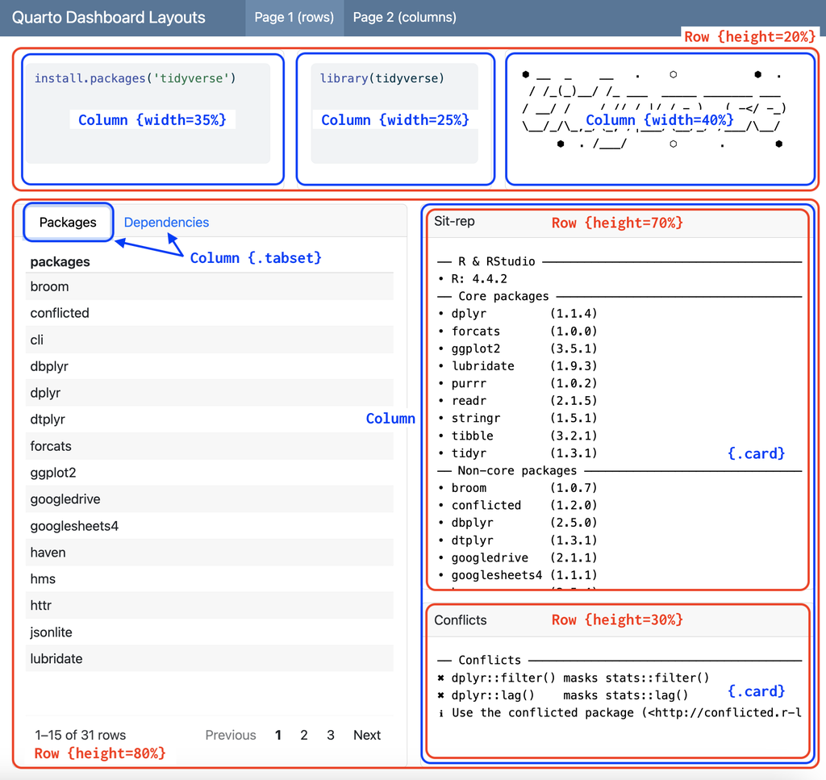

Quarto layout options page 1 (click to enlarge)

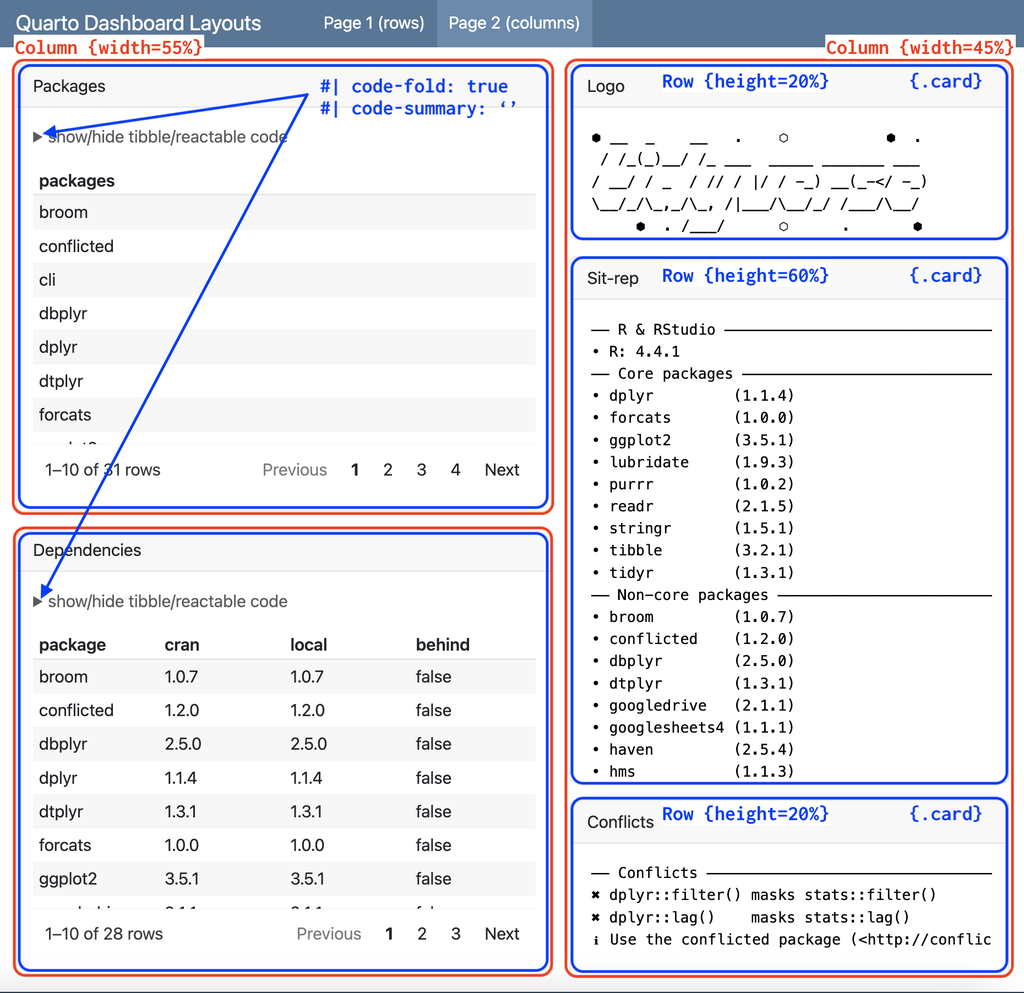

Quarto layout options page 2 (click to enlarge)

View the code used for the layout above (and others) in the GitHub repository.[^4]

## Reactivity

Quarto documents can be converted into Shiny’s apps using the `server` option in the YAML header. In our `index.qmd` file, we’ll set `server` to `shiny`:

### `server: shiny`

```yaml
---
title: "Movies App"
format: html
server: shiny
---
```

````
```{r}
#| context: server
```
````

## Modules

If you’re developing a Quarto + Shiny application using modules (and you should[^5] be[^6]), the module functions can be placed in the code blocks like regular Shiny code.

The code below is used to implement the UI functions from the `mod_var_input.R` and `mod_scatter_display_ui.R` modules:

````
```{r}
#| panel: input
mod_var_input_ui("vars")
```

```{r}
#| panel: center
mod_scatter_display_ui("plot")
```
````

The `panel: input` creates a ‘*div with class `.panel-input`* and `panel: center` will’*leave some horizontal margin around its content*.’[^7]

We can also include regular shiny code in code chunks:

````
```{r}
#| panel: fill
tags$br()
tags$em(
  "Built using ",
  tags$a(
    img(
      src = "www/quarto.png",
      height = 25,
      width = 90,
      style = "margin:10px 10px"
    ),
    href = "https://quarto.org/docs/interactive/shiny/"
  ),
  "and data from the ",
  tags$a("Building web applications with Shiny",
    href = "https://rstudio-education.github.io/shiny-course/"),
  "tutorial."
)
```
````

`panel: fill` will ‘*fill all available spac*e’ in the dashboard.[^8]

### `context: server`

The `server: shiny` in the YAML frontmatter ensures the document will render the UI inputs (i.e., the contents of `mod_var_input_ui()`). To differentiate the `server` (running on the back-end) code from user inputs and outputs, we need to add the module server functions in code blocks with the `context: server` option:

````
```{r}
#| context: server

selected_vars <- mod_var_input_server("vars")

mod_scatter_display_server("plot", var_inputs = selected_vars)
```
````

## Styling

SASS (Syntactically Awesome Style Sheets) or [CSS (Cascading Style Sheets)](https://en.wikipedia.org/wiki/CSS) can be powerful tools for customizing a Quarto dashboard’s appearance. Unlike standard CSS, SCSS introduces features like variables, nesting, and mixins, which help keep the code organized and modular.

### `styles.scss`

A dedicated `.scss` file keeps styles organized and separated from content, improving readability and maintainability.

```
└── inst
     └── quarto
          ├── _quarto.yml
          ├── index.qmd
          └── www
              ├── quarto.png
              └── styles.scss
```

We will set some colors defaults in `www/styles.scss`:

```
/*-- scss:defaults --*/

// colors
$body-bg: #070d35;
$body-color: #FFFFFF;

$link-color: #2ee3a4;
$hover-color: lighten($link-color, 40%);

$code-block-bg-alpha: -.8;

/*-- scss:rules --*/
```

### `thematic`

For a broader, simplified approach to styling, we can install/use the [`thematic`](https://rstudio.github.io/thematic/) package:

```r
install.packages("thematic")
```

We can add `thematic_set_theme()` to the `context: setup` code chunk in `index.qmd`:

```r
thematic::thematic_set_theme(
  theme = thematic::thematic_theme(
    bg = "#070d35",
    fg = "#FFFFFF",
    accent = "#2ee3a4"))
```

This also requires the `shiny.useragg` [option](https://rstudio.github.io/thematic/articles/fonts.html?q=shinyuseragg#shiny-rmd):

```r
options(shiny.useragg = TRUE)
```

## Launching

To launch our Quarto dashboard with a standalone app function, we can use `quarto_preview()` with `system.file()`:

```r
launch_app <- function() {
  quarto::quarto_preview(
    system.file("quarto", "index.qmd", package = "sap" ),
    render = "all")
}
```

```r
launch_app()
```

[figure not shown]

Quarto App (click to enlarge)

## Recap

If you’re interested in learning more, check out the [Quarto apps section](https://mjfrigaard.github.io/shiny-app-pkgs/resources.html#sec-resources-inst-quarto) of Shiny App-Packages and the Quarto documentation. Albert Rapp has a great video on [building interactive apps with Quarto & Shiny](https://youtu.be/06H8k1nzZQ0?si=vGKuE6VX1LdfDMP7) and Isabella Velásquez also does a fantastic job covering [python Quarto dashboards](https://youtu.be/uLGe9zuuNl0?si=8bC7qG3AvFDcmj2x).

## Footnotes

[^1]: Shiny is covered in the [Interactivity section](https://quarto.org/docs/interactive/shiny/) of the Quarto documentation.
[^2]: [Quarto dashboards.](https://quarto.org/docs/dashboards/)
[^3]: Mine Çetinkaya-Rundel has an excellent three part tutorial on Posit’s YouTube channel ([part 1](https://youtu.be/HW7QbqI4fH0?si=WuBui8y9uRjOVQzD), [part 2](https://www.youtube.com/watch?v=KdsQgwaY950), [part 3](https://www.youtube.com/watch?v=NigWSB-jG4Y&t=112s)).
[^4]: The [`.qmd` files ending in `layout`](https://github.com/search?q=repo%3Amjfrigaard%2Fquarto-dash-r+path%3A%22layout.qmd%22&type=code) are examples of various dashboard layouts.
[^5]: See the [Modularizing Shiny app code](https://shiny.posit.co/r/articles/improve/modules/) in the Shiny documentation.
[^6]: See the [Shiny modules chapter](https://mastering-shiny.org/scaling-modules.html) of Mastering Shiny.
[^7]: Read more about [Input Panel layouts](https://quarto.org/docs/interactive/layout.html#input-panel)
[^8]: Read more about [Sidebar Panel layouts](https://quarto.org/docs/interactive/layout.html#sidebar-panel).

[interactive chart not shown]